# Customizing nbconvert

Under the hood, nbconvert uses [Jinja templates](https://jinja2.readthedocs.io/en/latest/intro.html) to specify how the notebooks should be formatted. These templates can be fully customized, allowing you to use nbconvert to create notebooks in different formats with different styles as well.

## Converting a notebook to an (I)Python script and printing to stdout

Out of the box, nbconvert can be used to convert notebooks to plain Python files. For example, the following command converts the `example.ipynb` notebook to Python and prints out the result:

```python
!jupyter nbconvert --to python 'example.ipynb' --stdout
```

```
[NbConvertApp] Converting notebook example.ipynb to python

# coding: utf-8

# # Example notebook

# ### Markdown cells
#
# This is an example notebook that can be converted with `nbconvert` to different formats. This is an example of a markdown cell.

# ### LaTeX Equations
#
# Here is an equation:
#
# $$
# y = \sin(x)
# $$

# ### Code cells

# In[1]:


print("This is a code cell that produces some output")


# ### Inline figures

# In[1]:


import matplotlib.pyplot as plt
import numpy as np
plt.ion()

x = np.linspace(0, 2 * np.pi, 100)
y = np.sin(x)
plt.plot(x, y)
```

From the code, you can see that non-code cells are also exported. If you wanted to change that behaviour, you would first look to nbconvert configuration options page to see if there is an option available that can give you your desired behaviour.

```python
!jupyter nbconvert --to python 'example.ipynb' --stdout --TemplateExporter.exclude_markdown=True
```

```
[NbConvertApp] Converting notebook example.ipynb to python

# coding: utf-8

# In[1]:


print("This is a code cell that produces some output")


# In[1]:


import matplotlib.pyplot as plt
import numpy as np
plt.ion()

x = np.linspace(0, 2 * np.pi, 100)
y = np.sin(x)
plt.plot(x, y)
```

## Custom Templates

As mentioned above, if you want to change this behavior, you can use a custom template. The custom template inherits from the Python template and overwrites the markdown blocks so that they are empty.

Below is an example of a custom template, which we write to a file called `simplepython.tpl`. This template removes markdown cells from the output, and also changes how the execution count numbers are formatted:

```python
%%writefile simplepython.tpl

{% extends 'python.tpl'%}

## remove markdown cells
{% block markdowncell -%}
{% endblock markdowncell %}

## change the appearance of execution count
{% block in_prompt %}
# [{{ cell.execution_count if cell.execution_count else ' ' }}]:
{% endblock in_prompt %}
```

```
Overwriting simplepython.tpl
```

Using this template, we see that the resulting Python code does not contain anything that was previously in a markdown cell, and only displays execution counts (i.e., `[#]:` not `In[#]:`):

```python
!jupyter nbconvert --to python 'example.ipynb' --stdout --template=simplepython.tpl
```

```
[NbConvertApp] Converting notebook example.ipynb to python


# coding: utf-8

# [1]:

print("This is a code cell that produces some output")


# [1]:

import matplotlib.pyplot as plt
import numpy as np
plt.ion()

x = np.linspace(0, 2 * np.pi, 100)
y = np.sin(x)
plt.plot(x, y)
```

## Template structure

Nbconvert templates consist of a set of nested blocks. When defining a new template, you extend an existing template by overriding some of the blocks.

All the templates shipped in nbconvert have the basic structure described here, though some may define additional blocks.

```python
from IPython.display import HTML, display
with open('template_structure.html') as f:
    display(HTML(f.read()))
```

Main page

header

body

any_cell

codecell

input_group

in_prompt

input

output_group

output_prompt

outputs (see below)

any_cell

markdowncell

any_cell

rawcell

any_cell

unknowncell

⋮

footer

Outputs

outputs

output

execute_result

output

stream_stdout

output

stream_stderr

output

display_data

data_priority

data_pdf / data_svg / data_png / data_html / data_markdown / data_jpg / data_text / data_latex / data_javascript / data_other

output

error

traceback_line

⋮

⋮

Extra HTML blocks

basic.tpl

output

output_area_prompt

output (as above)

full.tpl

header

```
<head>
```

html_head

```
</head>
```

Extra Latex blocks

header

docclass

packages

definitions

title

date

author

commands

margins

body

predoc

maketitle

abstract

... other fields as above ...

postdoc

bibliography

### A few gotchas

Jinja blocks use `{% %}` by default which does not play nicely with LaTeX, so those are replaced by `((* *))` in LaTeX templates.

## Templates using cell tags

The notebook file format supports attaching arbitrary JSON metadata to each cell. In addition, every cell has a special `tags` metadata field that accepts a list of strings that indicate the cell’s tags. To apply these, go to the `View → CellToolbar → Tags` option which will create a Tag editor at the top of every cell.

First choose a notebook you want to convert to html, and apply the tags: `"Easy"`, `"Medium"`, or `"Hard"`.

With this in place, the notebook can be converted using a custom template.

Design your template in the cells provided below.

Hint: tags are located at `cell.metadata.tags`, the following Python code collects the value of the tag:

```python
cell['metadata'].get('tags', [])
```

Which you can then use inside a Jinja template as in the following:

```python
%%writefile mytemplate.tpl

{% extends 'full.tpl'%}
{% block any_cell %}
{% if 'Hard' in cell['metadata'].get('tags', []) %}
    <div style="border:thin solid red">
        {{ super() }}
    </div>
{% elif 'Medium' in cell['metadata'].get('tags', []) %}
    <div style="border:thin solid orange">
        {{ super() }}
    </div>
{% elif 'Easy' in cell['metadata'].get('tags', []) %}
    <div style="border:thin solid green">
        {{ super() }}
    </div>
{% else %}
    {{ super() }}
{% endif %}
{% endblock any_cell %}
```

```
Overwriting mytemplate.tpl
```

Now, if we collect the result of using nbconvert with this template, and display the resulting html, we see the following:

```python
example = !jupyter nbconvert --to html 'example.ipynb' --template=mytemplate.tpl --stdout
example = example[3:] # have to remove the first three lines which are not proper html
from IPython.display import HTML, display
display(HTML('\n'.join(example)))
```

Example notebook

Markdown cells

This is an example notebook that can be converted with `nbconvert` to different formats. This is an example of a markdown cell.

LaTeX Equations

Here is an equation:

$$ y = \sin(x) $$

Code cells

```
print("This is a code cell that produces some output")
```

```
This is a code cell that produces some output
```

Inline figures

```
import matplotlib.pyplot as plt
import numpy as np
plt.ion()

x = np.linspace(0, 2 * np.pi, 100)
y = np.sin(x)
plt.plot(x, y)
```

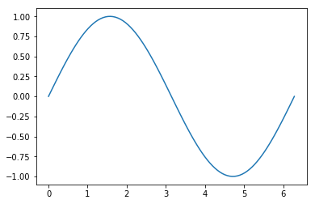

## Templates using custom cell metadata

We demonstrated above how to use cell tags in a template to apply custom styling to a notebook. But remember, the notebook file format supports attaching *arbitrary* JSON metadata to each cell, not only cell tags. Here, we describe an exercise for using an `example.difficulty` metadata field (rather than cell tags) to do the same as before (to mark up different cells as being “Easy”, “Medium” or “Hard”).

### How to edit cell metadata

To edit the cell metadata from within the notebook, go to the menu item: `View → Cell Toolbar → Edit Metadata`. This will bring up a toolbar above each cell with a button that says “Edit Metadata”. Click this button, and a field will pop up in which you will directly edit the cell metadata JSON.

**NB**: Because it is JSON, you will need to ensure that what you write is valid JSON.

### Template challenges: dealing with missing custom metadata fields

One of the challenges of dealing with custom metadata is to handle the case where the metadata is not present on every cell. This can get somewhat tricky because of JSON objects tendency to be deeply nested coupled with Python’s (and therefore Jinja’s) approach to calling into dictionaries. Specifically, the following code will error:

```python
foo = {}
foo["bar"]
```

Hint: if your metadata items are located at `cell.metadata.example.difficulty`, the following Python code would get the value defaulting to an empty string (`''`) if nothing is found:

```python
cell['metadata'].get('example', {}).get('difficulty', '')
```

### Exercise: Write a template for handling custom metadata

Now, write a template that will look for `Easy`, `Medium` and `Hard` metadata values for the `cell.metadata.example.difficulty` field and wrap them in a div with a green, orange, or red thin solid border (respectively).

**NB**: This is the same design and logic as used in the previous cell tag example.

#### How to get `example.ipynb`

We have provided an example file in `example.ipynb` in the nbconvert documentation that has already been marked up with both tags and the above metadata for you to test with. You can get it from [this link to the raw file](https://raw.githubusercontent.com/jupyter/nbconvert/master/docs/source/example.ipynb) or by cloning the repository [from GitHub](https://github.com/jupyter/nbconvert) and navingating to `nbconvert/docs/source/example.ipynb`.

#### Convert `example.ipynb` using cell tags

First, make sure that you can reproduce the previous result using the cell tags template that we have provided above.

**Easy**: If you want to make it easy on yourself, create a new file `my_template.tpl` in the same directory as `example.ipynb` and copy the contents of the cell we use to write `mytemplate.tpl` to the file system.

**Moderate**: If you want more of a challenge, try recreating the jinja template by modifying the following jinja template file:

```python
{% extends 'full.tpl'%}
{% block any_cell %}
    <div style="border:thin solid red">
        {{ super() }}
    </div>
{% endblock any_cell %}
```

**Hard**: If you want even more of a challenge, try recreating the jinja template from scratch.

#### Write your template

Once you’ve done at least the **Easy** version of the previous step, try modifying your template to use `cell.metadata.example.difficulty` fields rather than cell tags.

#### Convert `example.ipynb` with formatting from custom metadata

Once you’ve written your template, try converting `example.ipynb` using the following command (making sure that `your_template.tpl` is in your local directory where you are running the command):

```bash
jupyter nbconvert --to html 'example.ipynb' --template=your_template.tpl --stdout
```

The resulting display should pick out different cells to be bordered with green, orange, or red.

If you do that successfullly, the resulting html document should look like the following cell’s contents:

[output not shown]

```
<div style="border:thin solid red">
```

# Example notebook¶

```
</div>
```

### Markdown cells¶

This is an example notebook that can be converted with nbconvert to different formats. This is an example of a markdown cell.

### LaTeX Equations¶

Here is an equation:

$y = \sin(x)$

```
<div style="border:thin solid green">
```

### Code cells¶

```
</div>
```

```python
print("This is a code cell that produces some output")
```

```
This is a code cell that produces some output
```

### Inline figures¶

```
<div style="border:thin solid orange">
```

```python
import matplotlib.pyplot as plt
import numpy as np
plt.ion()

x = np.linspace(0, 2 * np.pi, 100)
y = np.sin(x)
plt.plot(x, y)
```

```
</div>
```

```
</div>
```